# ADP 8회 1번 문제 풀이

##### RFM(Recency, Frequency, Monetary)별로 상위 20%가 차지하는 총 매출액 비중 구하기

- 총 매출액(sumTotal)

```r
sumTotal <- sum(userRFM$monetary)
sumTotal
```

```
## [1] 136717990
```

- 1. Recency 별 상위 20%가 차지하는 매출액 비중 구하기
- recency(max(ymd_time))의 분위수 할당 후 결과 보기
- 날짜를 numeric으로 변환 후 분위수를 0.2, 0.4, 0.6, 0.8로 할당

```r
as.numeric(head(userRFM$recency))
```

```
## [1] 1344423600 1348714800 1339851600 1349053200 1349236800 1348542000
```

```r
## 1970-01-01 00:00:00을 기준으로 몇 초가 지났는지를 표시
```

```r
quantile(as.numeric(userRFM$recency), c(0.2, 0.4, 0.6, 0.8))
```

```
##        20%        40%        60%        80%
## 1343468160 1346289840 1347942960 1348999200
```

- 1. recency 상위 20%의 매출액의 비중 구하기
- recency 상위 20%의 매출액 합계( = sumR) 구하기

```r
top20_recency_monetary <- userRFM$monetary[userRFM$recency > quantile(userRFM$recency, 0.8)]
sum.top20_recency_monetary <- sum(as.numeric(top20_recency_monetary))
sumR <- sum.top20_recency_monetary
sumR
```

```
## [1] 58116079
```

- recency 상위 20%의 비중은…

```r
sumR / sumTotal
```

```
## [1] 0.42508
```

- 그러므로 recency 상위 20%의 비중은 약 43%임.
- 2. frequency 상위 20%가 차지하는 매출액 비중 구하기

```r
head(userRFM$frequency)
```

```
## [1]  1  4  2  9 15  1
```

```r
quantile(as.numeric(userRFM$frequency), c(0.2, 0.4, 0.6, 0.8))
```

```
## 20% 40% 60% 80%
##   1   3   5  12
```

```r
sumF <- sum(userRFM$monetary[userRFM$frequency > quantile(userRFM$frequency, 0.8)])
sumF / sumTotal
```

```
## [1] 0.5880298
```

- frequency 상위 20%가 차지하는 매출액 비중은 약 59%
- 3.monetary 상위 20%가 차지하는 매출액 비중 구하기

```r
sumM <- sum(userRFM$monetary[userRFM$monetary > quantile(userRFM$monetary, 0.8)])
sumM / sumTotal
```

```
## [1] 0.6410076
```

- monetary 상위 20%가 차지하는 매출액 비중은 약 64%
- 고객별 RFM score는 RFM 분야별 등급 점수에 가중치를 곱한 후 합산하여 산출
- RFM 별 가중치 구하기

```r
weightR<- sumR / (sumR + sumF + sumM) ## 0.256983
weightF <- sumF / (sumR + sumF + sumM) ## 0.3554946
weightM <- sumM / (sumR + sumF + sumM) ## 0.3875224
weightR + weightF + weightM ## 1 확인
```

```
## [1] 1
```

- RFM 별 고객점수 나누는 기준 구하기

```r
## recency quantile
quantR <- quantile(as.numeric(userRFM$recency), c(0, 0.2, 0.4, 0.6, 0.8, 1), origin = '1970-01-01 00:00:00')

## frequency guantile
quantF <- quantile(userRFM$frequency, c(0, 0.2, 0.4, 0.6, 0.8, 1))

## monetary quantitle
quantM <- quantile(userRFM$monetary, c(0, 0.2, 0.4, 0.6, 0.8, 1))
```

- 고개별 R score 구하기

```r
quantR
```

```
##         0%        20%        40%        60%        80%       100%
## 1333357200 1343468160 1346289840 1347942960 1348999200 1349614800
```

```r
num_recency <- as.numeric(userRFM$recency)
userRFM_1 <- cbind(userRFM, recency_num = num_recency)
userRFM_1 %>%
  mutate(R = ifelse(recency_num >= quantR[1] & recency_num < quantR[2], 1,
                    ifelse(recency_num >= quantR[2] & recency_num < quantR[3], 2,
                           ifelse(recency_num >= quantR[3] & recency_num < quantR[4], 3,
                                  ifelse(recency_num >= quantR[4] & recency_num < quantR[5], 4, 5))))) -> added_R
head(added_R)
```

```
##   custid          minRecency             recency monetary    period
## 1  C0001 2012-08-08 20:00:00 2012-08-08 20:00:00     5840   0.00000
## 2  C0002 2012-06-26 16:00:00 2012-09-27 12:00:00    90168  92.83333
## 3  C0003 2012-06-05 21:00:00 2012-06-16 22:00:00     9980  11.04167
## 4  C0004 2012-04-07 16:00:00 2012-10-01 10:00:00   201546 176.75000
## 5  C0005 2012-05-20 10:00:00 2012-10-03 13:00:00    93693 136.12500
## 6  C0006 2012-09-25 12:00:00 2012-09-25 12:00:00     3980   0.00000
##   frequency    minDate    maxDate recency_num R
## 1         1 2012-08-08 2012-08-08  1344423600 2
## 2         4 2012-06-26 2012-09-27  1348714800 4
## 3         2 2012-06-05 2012-06-16  1339851600 1
## 4         9 2012-04-07 2012-10-01  1349053200 5
## 5        15 2012-05-20 2012-10-03  1349236800 5
## 6         1 2012-09-25 2012-09-25  1348542000 4
```

- 고객별 F score 구하기

```r
quantF
```

```
##   0%  20%  40%  60%  80% 100%
##    1    1    3    5   12   79
```

```r
userRFM %>%
  mutate(F = ifelse(frequency >=  quantF[1] & frequency < quantF[2], 1,
                    ifelse(frequency >= quantF[2] & frequency < quantF[3], 2,
                           ifelse(frequency >= quantF[3] & frequency < quantF[4], 3,
                                  ifelse(frequency >= quantF[4] & frequency < quantF[5], 4, 5))))) -> added_F
head(added_F)
```

```
## # A tibble: 6 x 9
##   custid          minRecency             recency monetary    period
##    <chr>              <dttm>              <dttm>    <int>     <dbl>
## 1  C0001 2012-08-08 20:00:00 2012-08-08 20:00:00     5840   0.00000
## 2  C0002 2012-06-26 16:00:00 2012-09-27 12:00:00    90168  92.83333
## 3  C0003 2012-06-05 21:00:00 2012-06-16 22:00:00     9980  11.04167
## 4  C0004 2012-04-07 16:00:00 2012-10-01 10:00:00   201546 176.75000
## 5  C0005 2012-05-20 10:00:00 2012-10-03 13:00:00    93693 136.12500
## 6  C0006 2012-09-25 12:00:00 2012-09-25 12:00:00     3980   0.00000
## # ... with 4 more variables: frequency <int>, minDate <date>,
## #   maxDate <date>, F <dbl>
```

- 고객별 M score 구하기

```r
quantM[1]
```

```
## 0%
## 40
```

```r
quantM
```

```
##       0%      20%      40%      60%      80%     100%
##     40.0   7082.0  18996.0  43354.0 107766.6 827854.0
```

```r
userRFM %>%
  mutate(M = ifelse(monetary >=  quantM[1] & monetary < quantM[2], 1,
                    ifelse(monetary >= quantM[2] & monetary < quantM[3], 2,
                           ifelse(monetary >= quantM[3] & monetary < quantM[4], 3,
                                  ifelse(monetary >= quantM[4] & monetary < quantM[5], 4, 5))))) -> added_M
head(added_M)
```

```
## # A tibble: 6 x 9
##   custid          minRecency             recency monetary    period
##    <chr>              <dttm>              <dttm>    <int>     <dbl>
## 1  C0001 2012-08-08 20:00:00 2012-08-08 20:00:00     5840   0.00000
## 2  C0002 2012-06-26 16:00:00 2012-09-27 12:00:00    90168  92.83333
## 3  C0003 2012-06-05 21:00:00 2012-06-16 22:00:00     9980  11.04167
## 4  C0004 2012-04-07 16:00:00 2012-10-01 10:00:00   201546 176.75000
## 5  C0005 2012-05-20 10:00:00 2012-10-03 13:00:00    93693 136.12500
## 6  C0006 2012-09-25 12:00:00 2012-09-25 12:00:00     3980   0.00000
## # ... with 4 more variables: frequency <int>, minDate <date>,
## #   maxDate <date>, M <dbl>
```

```r
userRFM <- cbind(userRFM, R = added_R$R, F = added_F$F, M = added_M$M)
head(userRFM)
```

```
##   custid          minRecency             recency monetary    period
## 1  C0001 2012-08-08 20:00:00 2012-08-08 20:00:00     5840   0.00000
## 2  C0002 2012-06-26 16:00:00 2012-09-27 12:00:00    90168  92.83333
## 3  C0003 2012-06-05 21:00:00 2012-06-16 22:00:00     9980  11.04167
## 4  C0004 2012-04-07 16:00:00 2012-10-01 10:00:00   201546 176.75000
## 5  C0005 2012-05-20 10:00:00 2012-10-03 13:00:00    93693 136.12500
## 6  C0006 2012-09-25 12:00:00 2012-09-25 12:00:00     3980   0.00000
##   frequency    minDate    maxDate R F M
## 1         1 2012-08-08 2012-08-08 2 2 1
## 2         4 2012-06-26 2012-09-27 4 3 4
## 3         2 2012-06-05 2012-06-16 1 2 2
## 4         9 2012-04-07 2012-10-01 5 4 5
## 5        15 2012-05-20 2012-10-03 5 5 4
## 6         1 2012-09-25 2012-09-25 4 2 1
```

- score 계산

```r
userRFM$score <- (weightR * userRFM$R + weightF * userRFM$F + weightM * userRFM$M)*100/5
head(userRFM)
```

```
##   custid          minRecency             recency monetary    period
## 1  C0001 2012-08-08 20:00:00 2012-08-08 20:00:00     5840   0.00000
## 2  C0002 2012-06-26 16:00:00 2012-09-27 12:00:00    90168  92.83333
## 3  C0003 2012-06-05 21:00:00 2012-06-16 22:00:00     9980  11.04167
## 4  C0004 2012-04-07 16:00:00 2012-10-01 10:00:00   201546 176.75000
## 5  C0005 2012-05-20 10:00:00 2012-10-03 13:00:00    93693 136.12500
## 6  C0006 2012-09-25 12:00:00 2012-09-25 12:00:00     3980   0.00000
##   frequency    minDate    maxDate R F M    score
## 1         1 2012-08-08 2012-08-08 2 2 1 32.24955
## 2         4 2012-06-26 2012-09-27 4 3 4 72.89011
## 3         2 2012-06-05 2012-06-16 1 2 2 34.86034
## 4         9 2012-04-07 2012-10-01 5 4 5 92.89011
## 5        15 2012-05-20 2012-10-03 5 5 4 92.24955
## 6         1 2012-09-25 2012-09-25 4 2 1 42.52887
```

- score 점수 시각화(histogram)

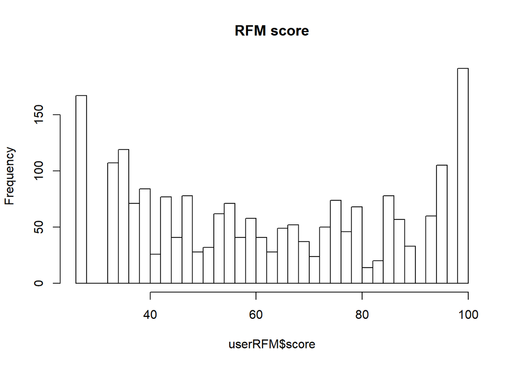

```r
hist(userRFM$score, breaks = 50, main = 'RFM score')
```

- 그러므로, 분석을 위한 파생변수 R(최근 거래 등급 점수), F(거래 빈도 등급 점수), M(매출 등급 점수), score(각 지수별 가중치 고려한 고객별 종합 점수) 등을 정의하였음.